# Funciones y Funcionales

Octubre, 2015

## Funcionales

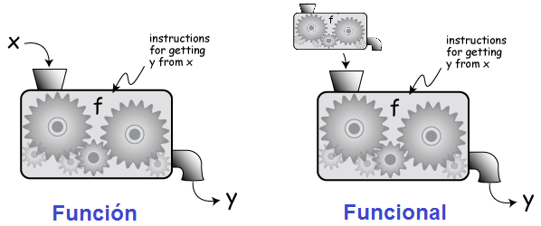

## Funcionales

- **Funcionales:**
  - `apply`: Aplica una función sobre los **márgenes** de un **array**.
  - `lapply`: Itera sobre una **lista** y aplica una función a **cada elemento**.
  - `sapply`: Análoga a `lapply`, pero simplifica el resultado a la estructura más sencilla.
  - `tapply`: Aplica una función sobre los subconjuntos (dados por un factor) de un vector.
  - `mapply`: Version multivariate de `lapply`.
- **Función auxiliar**:
  - `split`: Función auxiliar muy utilizada en conjunción con `lapply` o `sapply`.

## apply

- La función `apply` es usada para evaluar una función, frecuentemente anónima, sobre los **márgenes de un array**.
  - Puede utilizarse para **aplicar una función** a filas o columnas de una matriz.
- Se implementa en **una sola línea**`:)`.
- **No** es más rápida que un loop `:(`.

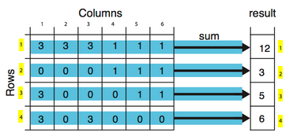

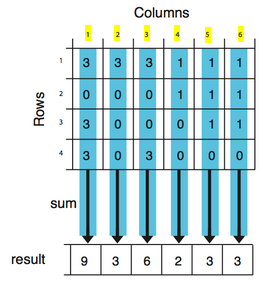

## apply

```r
str(apply)
```

```
## function (X, MARGIN, FUN, ...)
```

- **Argumentos:**
  - `X`: Un array.
  - `MARGIN`: Vector `integer` que especifica los márgenes a ser utilizados:
    - `1`: `fila`.
    - `2`: `columna`.
  - `FUN`: Función a ser aplicada a los elementos del margen seleccionado.
  - `...`: Argumentos adicionales que se pasan a `FUN`.
- **Return:**
  - Retorna un vector, lista o array de los valores obtenidos tras aplicar la función a los márgenes de un array.

## apply

- **Suma** de filas:

```r
mtx <- matrix(rnorm(50), 10, 5)
apply(X = mtx, MARGIN = 1, FUN = sum)
```

```
##  [1]  0.4165957 -0.8572427  0.6383684  1.7397350 -3.8112520 -2.4787440
##  [7] -0.6811188 -2.8606033 -1.5803474  4.2460340
```

- **Suma** de columnas:

```r
apply(X = mtx, MARGIN = 2, FUN = sum)
```

```
## [1]  3.7923161 -2.6117155 -2.1203870 -0.2883754 -4.0004134
```

## apply vs loop for

- Utilizar la función `apply` para calcular la **media** por columnas mediante:

```r
medias <- apply(X = mtx, MARGIN = 2, FUN = mean, na.rm = TRUE)
medias
```

```
## [1]  0.37923161 -0.26117155 -0.21203870 -0.02883754 -0.40004134
```

- Resulta equivalente a emplear el **loop**:

```r
medias <- numeric(ncol(mtx))
for (i in 1:ncol(mtx)){
    medias[i] <- mean(x = mtx[,i], na.rm = TRUE)
}
medias
```

```
## [1]  0.37923161 -0.26117155 -0.21203870 -0.02883754 -0.40004134
```

## col/row Sums/Means

- Para calcular las sumas o medias de las filas o columnas de un matriz se utilizan las funciones:
  - `rowSums(mtx)` \(\iff\) `apply(X=mtx, MARGIN=1, FUN=sum)`
  - `rowMeans(mtx)` \(\iff\) `apply(X=mtx, MARGIN=1, FUN=mean)`
  - `colSums(mtx)` \(\iff\) `apply(X=mtx, MARGIN=2, FUN=sum)`
  - `colMeans(mtx)` \(\iff\) `apply(X=mtx, MARGIN=2, FUN=mean)`
- conocidas como `shortcut functions`, que tienen la característica de ser *mucho* más rápidas (esto se evidencia al trabajar con matrices de gran volumen).

## col/row Sums/Means

- La línea de código para calcular la **media** por columnas:

```r
apply(X = mtx, MARGIN = 2, FUN = mean, na.rm = TRUE)
```

```
## [1]  0.37923161 -0.26117155 -0.21203870 -0.02883754 -0.40004134
```

- Resulta equivalente a:

```r
colMeans(x = mtx, na.rm = TRUE)
```

```
## [1]  0.37923161 -0.26117155 -0.21203870 -0.02883754 -0.40004134
```

## Ejemplos adicionales

- **Cuantiles** de las filas de una matriz.

```r
mtx <- matrix(rnorm(50), 10, 5)
apply(X = mtx, MARGIN = 1, FUN = quantile, probs = c(0.25, 0.75))
```

```
##           [,1]       [,2]      [,3]       [,4]         [,5]       [,6]
## 25% -0.5932782 -0.3108112 0.1254117 -0.5092881 -0.751826422 -0.9192656
## 75%  0.2086376  0.2752910 0.8795029  0.5990988 -0.003931317 -0.1663615
##           [,7]      [,8]       [,9]      [,10]
## 25% 0.05817703 -1.386646 -0.7501173 -0.1805159
## 75% 0.24630721  0.552468  0.6381014  1.0163658
```

## Ejercicios

- Lea el archivo `data_num.xlsx` y escriba un código que le permita solucionar los siguientes items:
  - Calcule el mínimo de cada fila.
  - Calcule el rango de cada columna.
  - Calcule el tipo de cada columna.
  - Realice un histograma para cada variable.

## lapply

- **Descripción:**
  - `lapply` permite aplicar una función a cada uno de los elementos de una lista `X`.

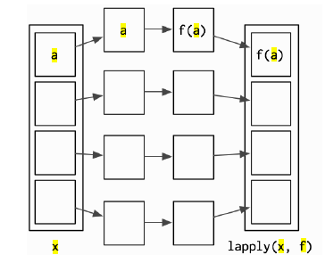

- Retorna una lista de la misma longitud que la lista input `f(X)`.

## lapply

```r
str(lapply)
```

```
## function (X, FUN, ...)
```

- **Argumentos:**
  - `X`: Una lista. Si no lo es será coercionado mediante `as.list()`.
  - `FUN`: es la función a ser aplicada a cada elemento de `X`.
  - `...`: argumentos adicionales que se pasan a `FUN`.
- **Return:**
  - Retorna una lista de la misma longitud que `X` con los valores obtenidos tras aplicar la función a cada uno de sus elementos.

**El funcional `lapply()`, actualmente se encuentra implementado en lenguaje `C`, de ahí su eficiencia.**

## lapply

- `lapply` siempre retorna una lista de la misma longitud que su input.
- **Media** de los elemtos de una lista:

```r
lst <- list(1:5, rnorm(10))
str(lst)
```

```
## List of 2
##  $ : int [1:5] 1 2 3 4 5
##  $ : num [1:10] 0.218 -0.141 0.258 0.499 1.42 ...
```

```r
lapply(X = lst, FUN = mean)
```

```
## [[1]]
## [1] 3
##
## [[2]]
## [1] 0.131154
```

## lapply

- **Rango** de los elemtos de una lista:

```r
lst <- list(a = 1:4, b = rnorm(10), c = rnorm(20, 1))
str(lst)
```

```
## List of 3
##  $ a: int [1:4] 1 2 3 4
##  $ b: num [1:10] 0.572 -2.413 -0.855 0.215 1.939 ...
##  $ c: num [1:20] 0.585 0.179 0.415 1.847 0.881 ...
```

```r
lapply(X = lst, FUN = range)
```

```
## $a
## [1] 1 4
##
## $b
## [1] -2.413075  1.938578
##
## $c
## [1] -1.228682  2.391860
```

## lapply

- Observaciones de una distribución \(Uniforme[0,1]\):

```r
str(runif)
```

```
## function (n, min = 0, max = 1)
```

```r
x <- 1:4
lapply(X = x, FUN = runif)
```

```
## [[1]]
## [1] 0.2596053
##
## [[2]]
## [1] 0.1631229 0.6332871
##
## [[3]]
## [1] 0.04038741 0.42453471 0.22339072
##
## [[4]]
## [1] 0.6520287 0.6886036 0.1466912 0.6190730
```

## lapply

- Observaciones de una distribución \(Uniforme[min,max]\):

```r
str(runif)
```

```
## function (n, min = 0, max = 1)
```

```r
x <- 1:4
lapply(X = x, FUN = runif, min = 0, max = 10)
```

```
## [[1]]
## [1] 3.476486
##
## [[2]]
## [1] 7.102772 3.426232
##
## [[3]]
## [1] 2.880840 8.285370 4.481729
##
## [[4]]
## [1] 0.3910719 4.1588099 9.4804056 6.9129632
```

## lapply y funciones anónimas

- Las **funciones anónimas** son comunmente utilizadas con `lapply`.

```r
(list.mtx <- list(a = matrix(1:4, 2, 2), b = matrix(1:6, 2, 3)))
```

```
## $a
##      [,1] [,2]
## [1,]    1    3
## [2,]    2    4
##
## $b
##      [,1] [,2] [,3]
## [1,]    1    3    5
## [2,]    2    4    6
```

- Función anónima para **extraer la primera fila** de una matriz.

```r
lapply(X = list.mtx, FUN = function(elem) elem[1,])
```

```
## $a
## [1] 1 3
##
## $b
## [1] 1 3 5
```

## sapply

- **Descripción:**
  - `sapply` funciona análogamente que `lapply`, pero **simplifica el resultado** a la estructura de datos más sencilla.

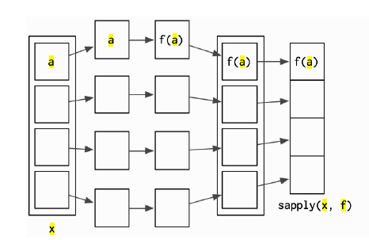

- **Simplificaciones comunes:**
  - `f(X)`: lista con elementos de longitud `1` \(\Rightarrow\) `f(X)`: vector atómico.
  - `f(X)`: lista con elementos de igual longitud `>1` \(\Rightarrow\) `f(X)`: matriz.
  - `f(X)`: lista, caso contrario

## sapply

```r
str(sapply)
```

```
## function (X, FUN, ..., simplify = TRUE, USE.NAMES = TRUE)
```

- **Argumentos:**
  - `X`: Una lista. Si no lo es será coercionado mediante `as.list()`.
  - `FUN`: es la función a ser aplicada a cada elemento de `X`.
  - `...`: argumentos adicionales que se pasan a `FUN`.
  - `simplify`: Si es `TRUE` se simplifica el resultado, si es `FALSE` es equivalente a `lapply`.
- **Return:**
  - Retorna una lista de la misma longitud que `X` con los valores obtenidos tras aplicar la función a cada uno de sus elementos. Simplica el resultado de ser posible.

## lapply y sapply

- **Media** de los elementos de una lista:

```r
lst <- list(a = 1:4, b = rexp(10,3), c = rpois(20, 2), d = rnorm(50,1,2))
lapply(X = lst, FUN = mean) #equivalente a sapply(lst, mean, simplify = FALSE)
```

```
## $a
## [1] 2.5
##
## $b
## [1] 0.3423247
##
## $c
## [1] 2.1
##
## $d
## [1] 0.6623656
```

```r
sapply(X = lst, FUN = mean)
```

```
##         a         b         c         d
## 2.5000000 0.3423247 2.1000000 0.6623656
```

## lapply y sapply

- **Rango** de los elementos de una lista:

```r
lst <- list(a = 1:4, b = rexp(10,3), c = rpois(20, 2), d = rnorm(50,1,2))
lapply(X = lst, FUN = range) #equivalente a sapply(lst, range, simplify = FALSE)
```

```
## $a
## [1] 1 4
##
## $b
## [1] 0.02084222 0.91190950
##
## $c
## [1] 0 6
##
## $d
## [1] -2.376733  6.646243
```

```r
sapply(X = lst, FUN = range)
```

```
##      a          b c         d
## [1,] 1 0.02084222 0 -2.376733
## [2,] 4 0.91190950 6  6.646243
```

## sapply

- **Máximo** de los elementos de una lista:

```r
lst <- list(a = 1:4, b = rexp(10,3), c = rpois(20, 2), d=rnorm(50,1,2))
```

```r
# máximo
sapply(X = lst, FUN = max, na.rm=TRUE)
```

```
##        a        b        c        d
## 4.000000 0.532853 4.000000 7.232194
```

- **Posición del máximo** en los elementos de una lista:

```r
# posición del máximo
sapply(X = lst, FUN = which.max)
```

```
##  a  b  c  d
##  4  1 16 45
```

## Ejercicios

- Genere 1, 2, 3, 4 observaciones de una distribución normal de parámetros `0`, `1`.
- Considerando la lista:

  ```r
  list(a = 5:1, b = rexp(10,2), c = rpois(20, 5))
  ```

  **extraer el mínimo y la desviación estándar** de cada elemento.
- Considerando la lista:

  ```r
  list(a = matrix(1:4, 2, 2), b = matrix(1:9, 3, 3))
  ```

  **extraer la diagonal principal** de cada elemento.

## Ejercicios prácticos

- Lea el archivo `data_funcl.xlsx` y genere un código para resolver los siguientes items:
  - Divida los datos en dos objetos:
    - `data_num`: Base con las variables numéricas.
    - `data_cat`: Base con las variables de tipo caracter.
  - Recodifique los `NAs` con -99 (debe ser parametrizable) en `data_num`.
  - Ordene cada columna de `data_num` ascendentemente.
  - Extraiga los registros únicos de cada columna de `data_num`.
  - Tabule cada una de las variables de `data_cat`.

## tapply

- **Descripción:**
  - `tapply` es utilizada para aplicar una función a distintos subconjuntos de un vector.

```r
str(tapply)
```

```
## function (X, INDEX, FUN = NULL, ..., simplify = TRUE)
```

- **Argumentos:**
  - `X`: Un vector atómico.
  - `INDEX`: Factor o lista de factores, permiten formar los subconjuntos.
  - `FUN`: es la función a ser aplicada a cada subconjunto de `X`.
  - `...`: argumentos adicionales que se pasan a `FUN`.
  - `simplify`: Si es `TRUE` el resultado se simplifica.
- **Return:**
  - Si `FUN` retorna un escalar, `tapply` retorna un vector atómico.
  - `tapply` retorna un arreglo tipo lista, caso contrario.

## tapply

```r
vec <- c(rnorm(10), runif(10), rnorm(10, 1))
# factor con n niveles con 10 observaciones cada uno
fac <- gl(n = 3, k = 10)
```

- **Media** de cada subconjunto:

```r
tapply(X = vec, INDEX = fac, FUN = mean)
```

```
##         1         2         3
## 0.2139393 0.5764574 0.5700904
```

- **Rango** de cada subconjunto:

```r
tapply(X = vec, INDEX = fac, FUN = range)
```

```
## $`1`
## [1] -1.197239  1.815055
##
## $`2`
## [1] 0.1107405 0.9688647
##
## $`3`
## [1] -1.039604  1.328860
```

## tapply

- Data set: `PlantGrowth`

```r
str(PlantGrowth)
```

```
## 'data.frame':    30 obs. of  2 variables:
##  $ weight: num  4.17 5.58 5.18 6.11 4.5 4.61 5.17 4.53 5.33 5.14 ...
##  $ group : Factor w/ 3 levels "ctrl","trt1",..: 1 1 1 1 1 1 1 1 1 1 ...
```

- **Varianza** de weight en los grupos dados por el factor group: ctrl, trt1, trt2

```r
tapply(X = PlantGrowth[,"weight"], INDEX = PlantGrowth[,"group"],FUN = var, na.rm = TRUE)
```

```
##      ctrl      trt1      trt2
## 0.3399956 0.6299211 0.1958711
```

```r
tapply(X = PlantGrowth[,"weight"], INDEX = PlantGrowth[,"group"],FUN = sd, na.rm = TRUE)
```

```
##      ctrl      trt1      trt2
## 0.5830914 0.7936757 0.4425733
```

## split

- **Descripción:**
  - `split` toma un objeto (vector, data frame) y lo divide en grupos dados por un factor.

```r
str(split)
```

```
## function (x, f, drop = FALSE, ...)
```

- **Argumentos:**
  - `x`: Un vector atómico, lista o data frame.
  - `f`: Factor o lista de factores, permite dividir el objeto `x`.
  - `drop`: Indica si los niveles vacíos serán reducidos.
- **Return:**
  - Retorna una lista que contiene el resultado de dividir `x` mediante `f`.

## split

- Split para un **vector numérico**:

```r
vec <- c(rnorm(5), runif(5), rexp(5, 1))
fac <- gl(n = 3, k = 5)
split(x = vec, f = fac)
```

```
## $`1`
## [1]  0.4017760 -1.2348152  0.2673516  0.3633442  0.2055167
##
## $`2`
## [1] 0.6217958 0.9376848 0.9317437 0.6852976 0.3612546
##
## $`3`
## [1] 1.5318520 0.0239642 1.6642608 0.9080808 1.2887303
```

- Retorna una **lista**:

```r
svec <- split(x = vec, f = fac)
str(svec)
```

```
## List of 3
##  $ 1: num [1:5] 0.402 -1.235 0.267 0.363 0.206
##  $ 2: num [1:5] 0.622 0.938 0.932 0.685 0.361
##  $ 3: num [1:5] 1.532 0.024 1.664 0.908 1.289
```

## split y lapply

```r
# split vector
svec <- split(x = vec, f = fac)
str(svec)
```

```
## List of 3
##  $ 1: num [1:5] 0.402 -1.235 0.267 0.363 0.206
##  $ 2: num [1:5] 0.622 0.938 0.932 0.685 0.361
##  $ 3: num [1:5] 1.532 0.024 1.664 0.908 1.289
```

```r
# media de cada subconjunto
lapply(X = svec, FUN = mean)
```

```
## $`1`
## [1] 0.0006346563
##
## $`2`
## [1] 0.7075553
##
## $`3`
## [1] 1.083378
```

## split, Data Frame

```r
library(datasets)
head(airquality,n = 10)
```

```
##    Ozone Solar.R Wind Temp Month Day
## 1     41     190  7.4   67     5   1
## 2     36     118  8.0   72     5   2
## 3     12     149 12.6   74     5   3
## 4     18     313 11.5   62     5   4
## 5     NA      NA 14.3   56     5   5
## 6     28      NA 14.9   66     5   6
## 7     23     299  8.6   65     5   7
## 8     19      99 13.8   59     5   8
## 9      8      19 20.1   61     5   9
## 10    NA     194  8.6   69     5  10
```

## split, Data Frame

- Se divide el data frame `airquality` mediante la variable `Month`:

```r
sairquality <- split(x = airquality, f = airquality$Month)
names(sairquality)
```

```
## [1] "5" "6" "7" "8" "9"
```

```r
head(sairquality[[1]], n = 3)
```

```
##   Ozone Solar.R Wind Temp Month Day
## 1    41     190  7.4   67     5   1
## 2    36     118  8.0   72     5   2
## 3    12     149 12.6   74     5   3
```

```r
head(sairquality[[2]], n = 3)
```

```
##    Ozone Solar.R Wind Temp Month Day
## 32    NA     286  8.6   78     6   1
## 33    NA     287  9.7   74     6   2
## 34    NA     242 16.1   67     6   3
```

## split y sapply, Data Frame

- Función a ser aplicada:

```r
# df es un data frame
media.df <- function(df,...){
  colMeans(df[, c("Ozone", "Solar.R", "Wind")],...)
}
```

- Se aplica la función `media.df` a los elementos de `sairquality`:

```r
sapply(X = sairquality, FUN = media.df)
```

```
##                5         6          7        8        9
## Ozone         NA        NA         NA       NA       NA
## Solar.R       NA 190.16667 216.483871       NA 167.4333
## Wind    11.62258  10.26667   8.941935 8.793548  10.1800
```

```r
sapply(X = sairquality, FUN = media.df, na.rm = TRUE)
```

```
##                 5         6          7          8         9
## Ozone    23.61538  29.44444  59.115385  59.961538  31.44828
## Solar.R 181.29630 190.16667 216.483871 171.857143 167.43333
## Wind     11.62258  10.26667   8.941935   8.793548  10.18000
```

## split y lapply, Data Frame

- Media de las variables utilizando una **función anónima**:

```r
lapply(sairquality, function(df) colMeans(df[, c("Ozone", "Solar.R", "Wind")],
                                 na.rm = TRUE))
```

```
## $`5`
##     Ozone   Solar.R      Wind
##  23.61538 181.29630  11.62258
##
## $`6`
##     Ozone   Solar.R      Wind
##  29.44444 190.16667  10.26667
##
## $`7`
##      Ozone    Solar.R       Wind
##  59.115385 216.483871   8.941935
##
## $`8`
##      Ozone    Solar.R       Wind
##  59.961538 171.857143   8.793548
##
## $`9`
##     Ozone   Solar.R      Wind
##  31.44828 167.43333  10.18000
```

## mapply

- **Descripción:**
  - `mapply` es la versión multivariante de `sapply`.
  - Aplica una función para los primeros elementos de cada argumento, para los segundos, terceros, …

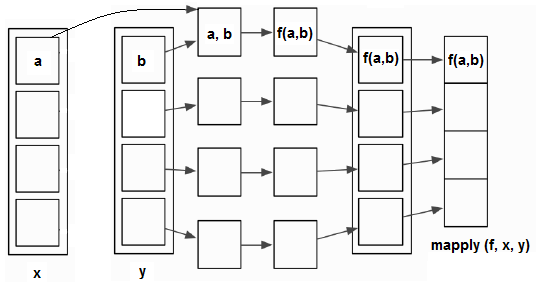

## mapply

```r
str(mapply)
```

```
## function (FUN, ..., MoreArgs = NULL, SIMPLIFY = TRUE, USE.NAMES = TRUE)
```

- **Argumentos:**
  - `FUN`: es la función a ser aplicada.
  - `...`: argumentos de `FUN`.
  - `MoreArgs`: argumentos adicionales para `FUN`.
  - `SIMPLIFY`: Si es `TRUE` el resultado se simplifica.
- **Return:**
  - Retorna una lista de la misma longitud que los argumentos `...` con los valores obtenidos tras aplicar la función a cada colección de elementos. Simplica el resultado de ser posible.

## mapply

- Función `rep.int` **escalar**:
- Recibe los argumentos `(x, times)`.

```r
str(rep.int)
```

```
## function (x, times)
```

- Repite `x` `times` veces

```r
rep.int(x = 1, times=2)
```

```
## [1] 1 1
```

```r
rep.int(x = 5, times=3)
```

```
## [1] 5 5 5
```

## mapply

- Aplico `rep.int` a cada uno de los pares \((valor_i,veces_i)\):

```r
valor <- 1:5
veces <- 5:1
mapply(FUN = rep.int, valor, veces, SIMPLIFY = TRUE)
```

```
## [[1]]
## [1] 1 1 1 1 1
##
## [[2]]
## [1] 2 2 2 2
##
## [[3]]
## [1] 3 3 3
##
## [[4]]
## [1] 4 4
##
## [[5]]
## [1] 5
```

## Ejercicios

- Considere la data `PlantGrowth` y calcule la **media** de la variable weight en cada uno de los grupos dados por la variable group.
- Considere la data `airquality` y calcule la **correlación** entre las variables Ozone y Solar.R en cada uno de los grupos dados por la variable Month.

## Vectorización de funciones escalares

- **Descripción**:
  - Crea una función que vectoriza la acción de su argumento `FUN` (función escalar).

```r
str(Vectorize)
```

```
## function (FUN, vectorize.args = arg.names, SIMPLIFY = TRUE, USE.NAMES = TRUE)
```

- **Argumentos:**
  - `FUN`: es la función a ser aplicada.
  - `vectorize.args`: vector caracter con los nombres de los argumentos de `FUN` a ser vectorizados.
  - `SIMPLIFY`: Si es `TRUE` se simplifica el resultado.
- **Return:**
  - Retorna una función con los mismos argumentos que `FUN`.

## Vectorización de funciones escalares

- Función exponencial **escalar**:

```r
x <- 1
exp(x)
```

```
## [1] 2.718282
```

- Función exponencial **vectorizada**:

```r
x <- 1:5
exp(x)
```

```
## [1]   2.718282   7.389056  20.085537  54.598150 148.413159
```

## Vectorización de funciones escalares

- Función `rep.int` **escalar**:
- `times` es un número.

```r
str(rep.int)
```

```
## function (x, times)
```

```r
rep.int(x = 1, times=2)
```

```
## [1] 1 1
```

- `times` es un vector.

```r
rep.int(x = 1, times=c(2,3))
```

```
## Error in rep.int(x = 1, times = c(2, 3)): valor de 'times' no válido
```

## Vectorización de funciones escalares

- Función `rep.int` **vectorial**:

```r
vrep <- Vectorize(FUN = rep.int, vectorize.args = "times", SIMPLIFY = TRUE)
# times es un vector
vrep(x = 1, times = c(2, 3, 4, 5))
```

```
## [[1]]
## [1] 1 1
##
## [[2]]
## [1] 1 1 1
##
## [[3]]
## [1] 1 1 1 1
##
## [[4]]
## [1] 1 1 1 1 1
```

## Ejercicios

- Vectorice la función para obtener el promedio de `2` números.
- Vectorice la función para obtener el máximo de `3` números.